# Презентация по лабораторной работе №1

Основы информационной безопасности

Черная С.В.

Российский университет дружбы народов, Москва, Россия

8 марта 2025

# Информация

## Докладчик

- Черная София Витальевна
- студентка группы НКАбд-01-23
- Российский университет дружбы народов

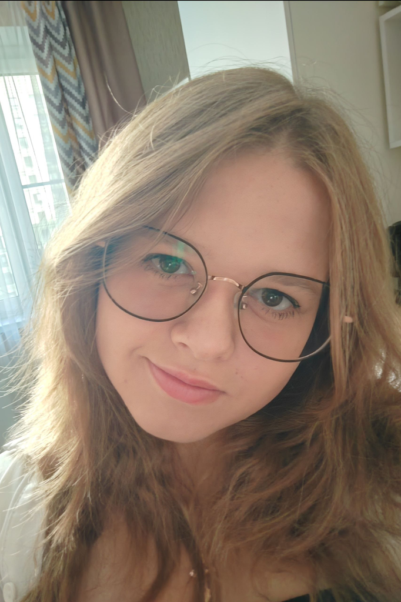

Черная София Витальевна

# Цель работы

Получение практических навыков работы в консоли с атрибутами фай- лов, закрепление теоретических основ дискреционного разграничения до- ступа в современных системах с открытым кодом на базе ОС Linux.

# Задание

1. Создание новой учетной записи guest
2. Работа с атрибутами файлов
3. Работа над созданием
4. Заполнение таблицы «Установленные права и разрешённые действия»
5. Определение тех или иные минимально необходимых прав для выполнения операций внутри директории dir1

# Теоретическое введение

В операционной системе Linux команда lsattr отображает характеристики атрибутов и их возможные значения для устройств в системе. Использование в Linux команды lsattr

На практике команда lsattr принимает в качестве аргументов имена файлов и каталогов для проверки. Если мы не указываем файл, он проверяет атрибуты текущего рабочего каталога.

В результате команда lsattr отображает по одному символу для каждого атрибута, чтобы указать, включён этот атрибут или нет:

oleg@mobile:~:$ lsattr abc.txt ————–e——- abc.txt oleg@mobile:~:$

Однако lsattr не показывает имена атрибутов. Таким образом, нам, возможно, придётся знать значение каждого буквенного кода, чтобы интерпретировать вывод.

Права доступа делятся на три группы:

```
user — права владельца файла;
group — права группы, которой принадлежит файл;
other — права всех остальных пользователей системы.
```

Стандартными правами доступа являются:

```
для файлов — 644 (rw-r—r—);
для директорий — 755 (rwxr-xr-x).
```

# Выполнение лабораторной работы

## Задание 1

В установленной при выполнении предыдущей лабораторной работы операционной системе Rocky создаю учётную запись пользователя guest (используя учётную запись администратора):useradd guest

## Задание 2

Задаю пароль для пользователя guest (использую учётную запись администратора) с помощью команды: passwd guest

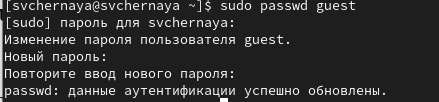

Password

## Задание 3

Вхожу в систему от имени пользователя guest

[figure not shown]

Guest

## Задание 4

Определяю директорию, в которой я нахожусь, командой pwd. Результат получаю : /home/guest. Однако в приглашении командной строчки стоит знак ~ , указывающий, что данная директория является домашней

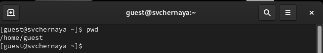

pwd

Проверяю, на всякий случай, командой перехода в домашнюю директорию : cd ~. Директория, в которой мы находились, не изменилась, что свидетельствует о том, что мы действительно находимся в домашней директории

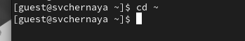

cd ~

## Задание 5

Уточняю имя моего пользователя командой whoami

## Задание 6

Уточняю имя моего пользователя, его группу, а также группы, куда вхо- дит пользователь, командой id. Выведенные значения uid, gid и др. за- помнинаю. Сравниваю вывод id с выводом команды groups. Замечаю, что с помощью команды id можно узнать больше информации о пользователе guest и его группы

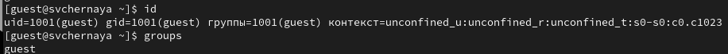

id, groups

## Задание 7

Сравниваю полученную информацию об имени пользователя с данными, выводимыми в приглашении командной строчки и замеча, что они совпадают

## Задание 8

Просматриваю файл /etc/passwd командой cat /etc/passwd. Нахожу в нем свою учетную запись(выделено красным), определяю, что uid пользователя и gid пользователя равны 1001. Они совпадают с запомненными мною ранее при выводе с помощью команды id

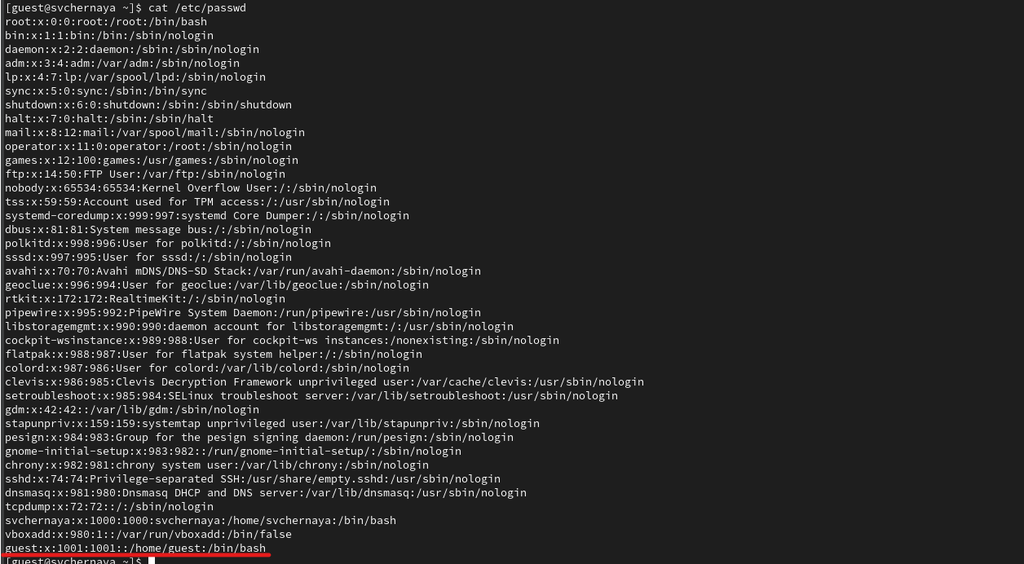

/etc/passwd

Проверяю себя с помощью команлы cat /etc/passwd | grep guest. Убеждаюсь, что я все определила верно

## Задание 9

Вывожу список поддиректорий директории /home и их права. Замечаю, что все права есть только у создателя директории, у группы и остальных пользователей никаких прав нет

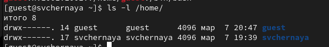

Список поддиректорий директории /home

## Задание 10

Проверяю есть ли какие-нибудь расширенные атрибуты на поддерикториях с помощью команды lsattr. Нет, никаких атрибутов у поддиректорий нет. Увидеть расширенные атрибуты у других пользователей так же не удалось

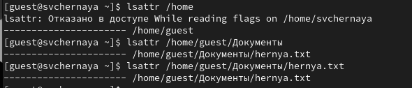

Просмотр атрибутов с помощью команды lsattr

## Задание 11

Создаю в домашней директории поддиректорию dir1 с помощью команды mkdir. Определеяю командами ls -l и lsattr какие права доступа и расширенные атрибуты были выставлены на директорию dir1. С помощью команды ls -l узнаю, что у создателя есть все права(на чтение, на записывание и на заход в директорию). У группы и остальных пользователей есть те же права, кроме записывания(создания файлов или удаление например). Команда lsattr ничего не выводит

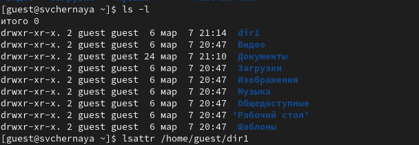

Права

## Задание 12

Снимаю все атрибуты с директории dir1 с помощью команды chmod 000 dir1. Проверяю права доступа с помощью ls -l/Замечаю, что теперь у всех нет прав ни на что

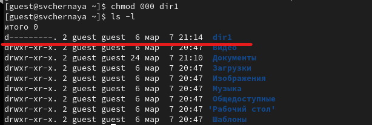

chmod 000

## Задание 13

Пытаюсь создать в директории dir1 файл fil1 командой echo “test” > /home/guest/dir1/file1. Отказ в доступе происходит из-за команды chmod 000, которая убирает все права у всех пользователей. Так же ls -l /home/guest/dir1 показывает, что файла нет

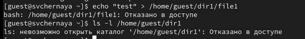

Попытка создать файл fil1 в dir1

## Задание 14

| Права директории | Права файла | Создание файла | Удаление файла | Запись в файл | Смена директории | Просмотр файлов в директории | Переименование файла | Смена атрибутов файла |
| --- | --- | --- | --- | --- | --- | --- | --- | --- |
| d(000) | (000) | - | - | - | - | - | - | - |
| d(000) | (100) | - | - | - | - | - | - | - |
| d(000) | (200) | - | - | - | - | - | - | - |
| d(000) | (300) | - | - | - | - | - | - | - |
| d(000) | (400) | - | - | - | - | - | - | - |
| d(000) | (500) | - | - | - | - | - | - | - |
| d(000) | (600) | - | - | - | - | - | - | - |
| d(000) | (700) | - | - | - | - | - | - | - |
| d(100) | (000) | - | - | - | - | + | - | - |
| d(100) | (100) | - | - | - | - | + | - | - |
| d(100) | (200) | - | - | + | - | + | - | - |
| d(100) | (300) | - | - | + | - | + | - | - |
| d(100) | (400) | - | - | - | + | + | - | - |
| d(100) | (500) | - | - | - | + | + | - | - |
| d(100) | (600) | - | - | + | + | + | - | - |
| d(100) | (700) | - | - | + | + | + | - | - |
| d(200) | (000) | - | - | - | - | - | - | - |
| d(200) | (100) | - | - | - | - | - | - | - |
| d(200) | (200) | - | - | - | - | - | - | - |
| d(200) | (300) | - | - | - | - | - | - | - |
| d(200) | (400) | - | - | - | - | - | - | - |
| d(200) | (500) | - | - | - | - | - | - | - |
| d(200) | (600) | - | - | - | - | - | - | - |
| d(200) | (700) | - | - | - | - | - | - | - |
| d(300) | (000) | + | + | - | - | + | - | + |
| d(300) | (100) | + | + | - | - | + | - | + |
| d(300) | (200) | + | + | + | - | + | - | + |
| d(300) | (300) | + | + | + | - | + | - | + |
| d(300) | (400) | + | + | - | + | + | - | + |
| d(300) | (500) | + | + | - | + | + | - | + |
| d(300) | (600) | + | + | + | + | + | - | + |
| d(300) | (700) | + | + | + | + | + | - | + |
| d(400) | (000) | - | - | - | - | - | + | - |
| d(400) | (100) | - | - | - | - | - | + | - |
| d(400) | (200) | - | - | - | - | - | + | - |
| d(400) | (300) | - | - | - | - | - | + | - |
| d(400) | (400) | - | - | - | - | - | + | - |
| d(400) | (500) | - | - | - | - | - | + | - |
| d(400) | (600) | - | - | - | - | - | + | - |
| d(400) | (700) | - | - | - | - | - | + | - |
| d(500) | (000) | - | - | - | - | + | + | - |
| d(500) | (100) | - | - | - | - | + | + | - |
| d(500) | (200) | - | - | + | - | + | + | - |
| d(500) | (300) | - | - | + | - | + | + | - |
| d(500) | (400) | - | - | - | + | + | + | - |
| d(500) | (500) | - | - | - | + | + | + | - |
| d(500) | (600) | - | - | + | + | + | + | - |
| d(500) | (700) | - | - | + | + | + | + | - |
| d(600) | (000) | - | - | - | - | - | + | - |
| d(600) | (100) | - | - | - | - | - | + | - |
| d(600) | (200) | - | - | - | - | - | + | - |
| d(600) | (300) | - | - | - | - | - | + | - |
| d(600) | (400) | - | - | - | - | - | + | - |
| d(600) | (500) | - | - | - | - | - | + | - |
| d(600) | (600) | - | - | - | - | - | + | - |
| d(600) | (700) | - | - | - | - | - | + | - |
| d(700) | (000) | + | + | - | - | + | + | + |
| d(700) | (100) | + | + | - | - | + | + | + |
| d(700) | (200) | + | + | + | - | + | + | + |
| d(700) | (300) | + | + | + | - | + | + | + |
| d(700) | (400) | + | + | - | + | + | + | + |
| d(700) | (500) | + | + | - | + | + | + | + |
| d(700) | (600) | + | + | + | + | + | + | + |
| d(700) | (700) | + | + | + | + | + | + | + |

## Задание 15

[output not shown]

# Выводы

Были получены практические навыки работы в консоли с атрибутами файлов, закреплены теоретические основы дискреционного разграничения доступа в современных системах с открытым кодом на базе ОС Linux.